# Introduction to R

### Functions (and conditionals)

Now suppose we wanted to do a similar analysis for other neighborhoods. In that case we should encapsulate the summaries and plots we want to do in a function:

```r
analyze_neighborhood <- function(neighborhood) {
  neighborhood_index <- arrest_tab$neighborhood == neighborhood
  neighborhood_tab <- arrest_tab[neighborhood_index,]

  # actually, we only want to make the plots for neighborhoods where there are more arrests for whites than blacks, let's use a conditional expression
  if (sum(neighborhood_tab$race == "W") >
      sum(neighborhood_tab$race == "B")) {

    boxplot(neighborhood_tab$age~neighborhood_tab$sex,
            main = neighborhood,
            xlab = "Sex", ylab="Arrest Age")

    barplot(table(neighborhood_tab$race),
            main = neighborhood,
            xlab = "Race", ylab="Number of Arrests")
  }
}
```

Now we can use that function to make our plots for specific neighborhoods

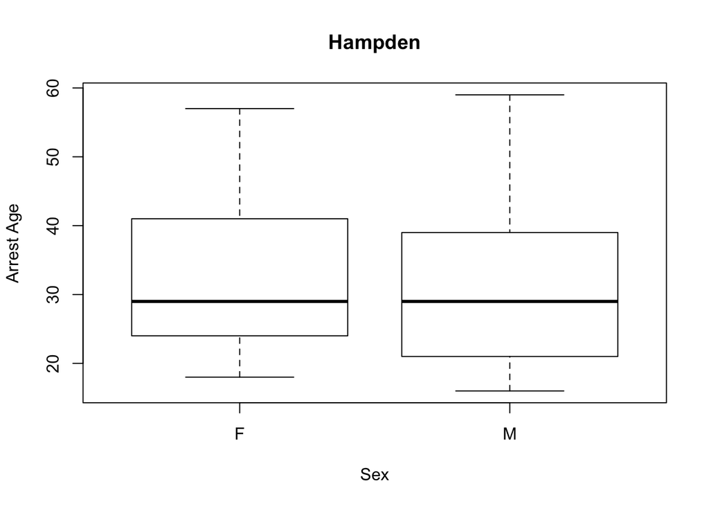

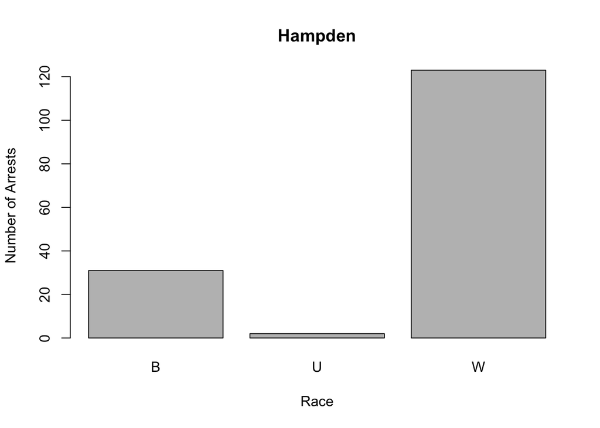

```r
analyze_neighborhood("Mount Washington")
analyze_neighborhood("Hampden")
```

## Loops

Finally, we can use a for loop to make these plots for all neighborhoods in the dataset and save them to a pdf file

```r
neighborhoods <- unique(arrest_tab$neighborhood)

# open a pdf file and save all plots to that file from
# this point until file is closed
pdf("neighborhood_analysis.pdf", width=6, height=6)
for (neighborhood in neighborhoods) {
  analyze_neighborhood(neighborhood)
}
# close the pdf file (plots will now be displayed in Rstudio again)
dev.off()
```

## Next up

On the intricacies of vectorized operations and loops. Matrices and other numerical computing facilities.